# What job does the cutter actually do?

2024–2026 regular season

Henry Blaney

## Question

I wanted to know whether cutters get called strikes or whiffs, and whether pitchers throw them in counts that do not match that. The example I had in mind was finishing an at-bat with a cutter that only gets taken for strikes.

Run value is `delta_pitcher_run_exp` (pitcher side; I did not flip it). Called strike means they took it and it was a strike. Whiff means swinging strike, not foul tip. Pitcher-years need 150 cutters.

## Data

Regular-season Statcast, 2024–2026. About 169,000 cutters. 391 pitcher-years after the 150 cutoff. I have two year-to-year comparisons from that. I did not pull 2022 or 2023.

## Called strikes and whiffs

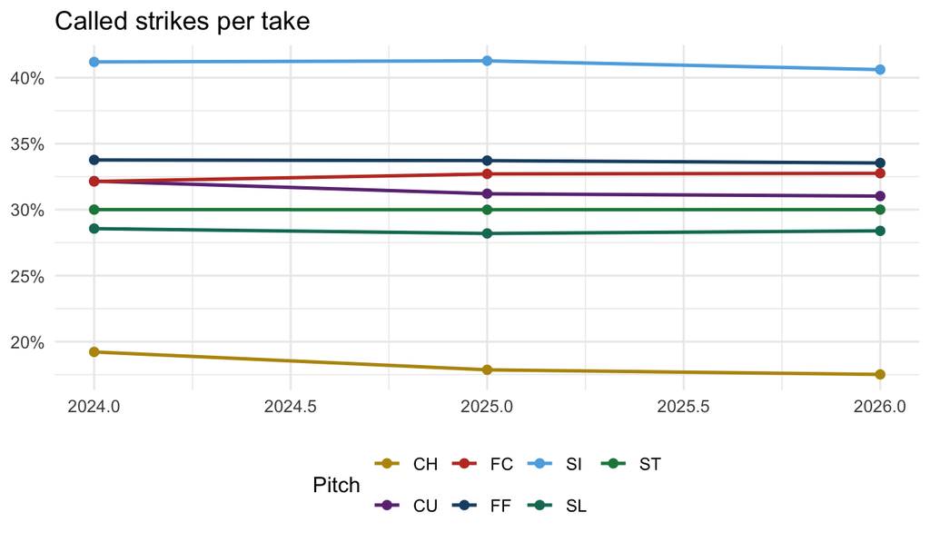

Called-strike rate on takes, by pitch type.

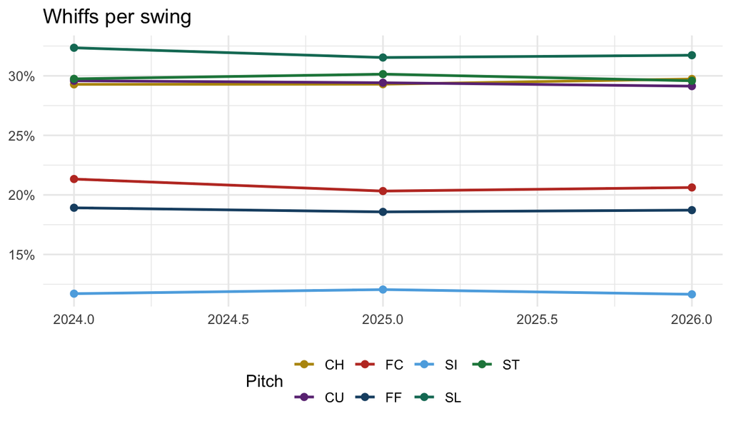

Whiff rate on swings, by pitch type.

On takes, the cutter’s called-strike rate is about 33%, next to four-seams. On swings it whiffs about 21%, also next to four-seams. Sliders are lower on called strikes and much higher on whiffs.

Behind vs two strikes. 2024–2026 pooled.

| Pitch | Count | N | CS / take | Whiff / swing | RV / 100 |
| --- | --- | --- | --- | --- | --- |
| Cutter | Behind | 45,649 | 40.2% | 20.2% | 0.13 |
| Cutter | Two strikes | 34,844 | 11.0% | 20.2% | -0.03 |
| Four-seam | Behind | 154,836 | 43.1% | 16.9% | -0.03 |
| Four-seam | Two strikes | 204,036 | 13.7% | 18.0% | -0.21 |
| Slider | Behind | 56,460 | 40.6% | 33.2% | 0.03 |
| Slider | Two strikes | 100,003 | 7.9% | 28.5% | 0.38 |

With two strikes the cutter still whiffs 20% of swings, same as when the pitcher is behind. The slider in that count is 29% whiffs and +0.38 runs per 100. The cutter is about zero. The four-seam is −0.21.

## Usage and labels

On the 150-plus pitcher-years, called-strike rate and whiff rate correlate **-0.20**. Called-strike rate and zone rate correlate **0.74**. Most of the “strike” split is location.

I thought the high called-strike guys might be using it too much with two strikes. They are not. Higher called-strike rate goes with less two-strike use (`r` = **-0.31**). Higher whiff rate goes with more (`r` = **0.42**).

Two-strike share year to year is **0.70** then **0.65**. Last year’s whiff rate predicts this year’s two-strike share. Called-strike rate is around 0.5 year to year. Run value is about zero. If I split guys at the median into strike-leaning and whiff-leaning, about half keep the same label next year (**48.5%**, **45.1%**), and the label does not predict next year’s run value.

I also built a same-year table of those labels by count. Strike-leaning looked bad with two strikes. That uses this year’s rates to make the label and this year’s pitches to score it, so I am leaving it out. `select(type)` after baseballr does not keep your column; I used `transmute(cutter_type = type)`.

## Location

Glove-side is the way the cutter breaks. For a right-hander that is first base: away from a right-handed hitter, in on a left-handed hitter. I had that backwards at first and said same-handed glove was in on the hands. Same-handed glove is away. Opposite-handed glove is in. Arm-side is the other half (including backdoor to a lefty). The pitch still cuts glove-side. This is just where it crosses the plate.

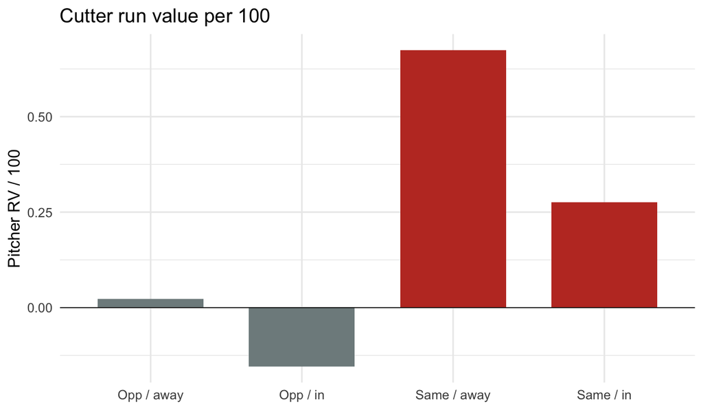

Run value per 100 cutters by matchup and plate half.

Pitcher-years with 150 or more cutters. Glove is the half the pitch breaks toward.

| Cell | N | CS / take | Whiff / swing | RV / 100 |
| --- | --- | --- | --- | --- |
| Opposite-handed, away (arm) | 33,003 | 40.0% | 21.7% | 0.02 |
| Opposite-handed, in (glove) | 46,619 | 25.2% | 17.3% | -0.15 |
| Same-handed, in (arm) | 13,149 | 49.2% | 17.6% | 0.28 |
| Same-handed, away (glove) | 41,692 | 28.5% | 25.8% | 0.67 |

Same-handed away has the best run value. Opposite-handed in has the worst. Arm-side rows have the highest called-strike rates; those pitches are in the zone more often.

This is the whole glove-side half, not just a pitch on the hands. Whiffs and run value are on the away, same-handed side.

Same pitcher, both glove-side versions, 25 or more pitches in each cell (354 pitcher-years):

- Away / same-handed: **0.51** RV / 100
- In / opposite-handed: **-0.47**
- Difference **0.98** per 100 (paired t, p = 1.2e-05)
- Whiffs **8.2%** higher on the away one
- Called-strike rate is not higher on the in version

## So what?

Called-strike and whiff rates sit near the four-seam. With two strikes the cutter’s whiff rate does not go up; the slider row is still +0.38 per 100. Extra value in this file is glove-side and away from the same-handed hitter. One season of rates is not enough to relabel a pitcher and change his counts. Two-strike usage already follows whiff rate.

## Limits

The 150 cutoff drops light cutter use. 2026 called-strike rates can differ from 2024–2025 because of ABS / the plate-location change; that is why the first graphs are by year. Median types do not hold next year. The location table is a half of the plate. No sequencing. Public Statcast.